# MSBMI 33200: Lecture 5

Anoop Mayampurath

November 4, 2019

## Decision Trees

Decision trees are a simple and useful modeling technique that can handle non-linearity, noise, and missing values.

They are fast and also interpretable.

They can be used for both classification and regression.

## Example

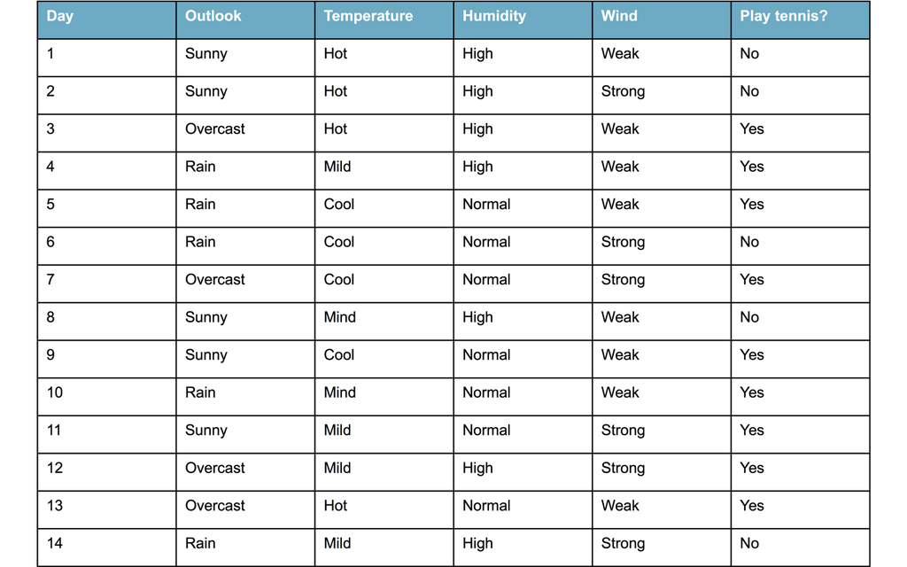

## Tree

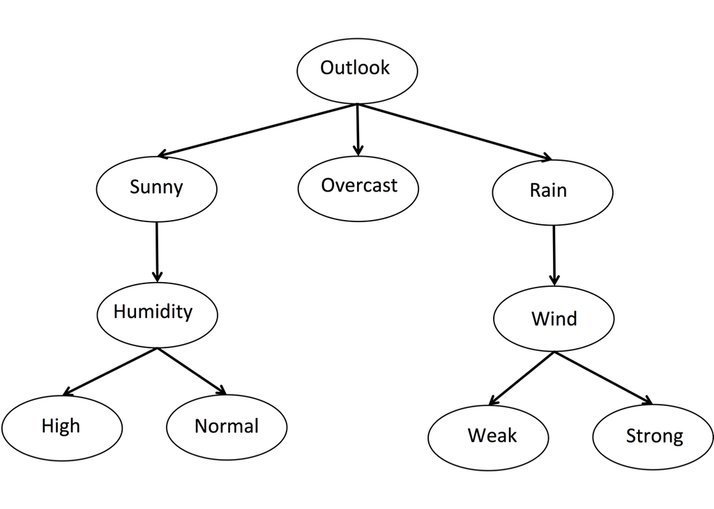

From the tree we can create decicsion rules as follows,

if (Outlook == Sunny $\bigwedge$ Humidity == Normal) $\bigvee$  
if (Outlook == Overcast) $\bigvee$  
if (Outlook == Rain $\bigwedge$ Wind == Week),  
then Play Tennis? = Yes

These are in what are called Conjuctive Normal Form (CNF)

## Decision Trees are…

1. Top-down
2. Greedy
3. Locally linear but globally non-linear

## Regression trees

We partition the feature space into a set of non-overlapping regions in a greedy manner to minimize overall RSE.

We do this by deciding at every split, pick predictor $X_j$ and a cutpoint $t$ is that minimizes

$$\sum_{i: x_i \in R_{1}} (y_i - \hat{y}_1) + \sum_{i: x_i \in R_{2}} (y_i - \hat{y}_2)$$

where,
$$R_1 = {X | X_j \leq t}$$
$$R_2 = {X | X_j > t}$$
$$\hat{y}_1 = \textit{average}(y_i | x_i \in R_{1})$$
$$\hat{y}_2 = \textit{average}(y_i | x_i \in R_{2})$$

This is called as recursive binary splitting.

## Classification trees

In case of a binary outcome, the objective would be to maximize representation of one class in one node of the tree. This is called as purity of the node. This is done using two methods:

1. Entropy
2. Gini-Index

## Using entropy to grow the tree

Definition: For a set $A$ with $i$ elements, entropy is defined as

$$E = -\sum_{i \in A}p_ilog(p_i)$$

In binary classification problems with two classes + and -:

$$E = -[p_{+}log(p_{+}) + p_{-}log(p_{-})]$$

$E$ values of 0 are maximal pure, whereas $E = 1$ indicates minimal purity (equal membership).

Here is a figure that helps recognizing entropy for different splits of class labels (from Provost & Fawcett, Data Science for Business: What You Need to Know about Data Mining and Data-Analytic Thinking and https://towardsdatascience.com/entropy-how-decision-trees-make-decisions-2946b9c18c8)

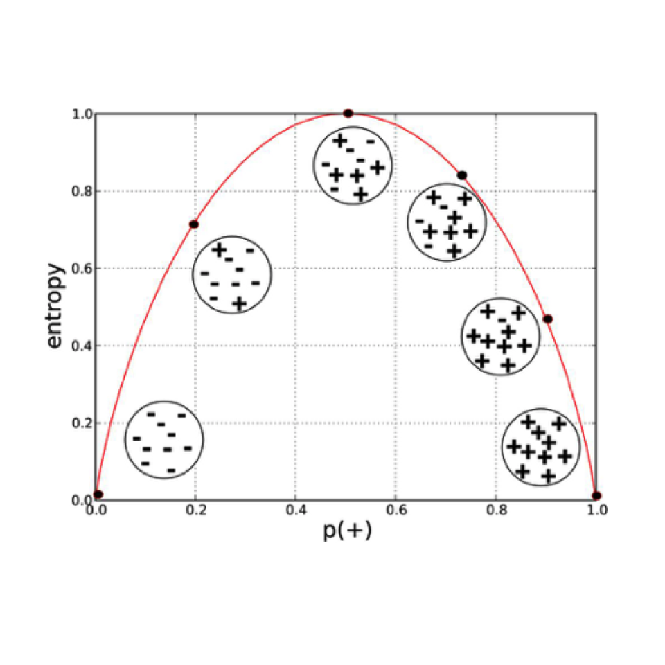

Consider the variable Outlook

1. Outlook = Sunny (2 yes, 3 no)
   $$E = -(\frac{2}{5})log(\frac{2}{5})-(\frac{3}{5})log(\frac{3}{5}) = 0.971$$
2. Outlook = Overcast (4 yes, 0 no)

$$E = -(\frac{4}{4})log(\frac{4}{4}) - 0 = 0$$

3. Outlook = Rainy (3 yes, 2 no)
   $$E = -(\frac{3}{5})log(\frac{3}{5})-(\frac{2}{5})log(\frac{2}{5}) = 0.971$$

## Using entropy to grow the tree (contd.)

We calculate average entropy of information content for predictor $A$ with $S$ samples

$$I(S, A) = \sum_i\frac{|S_i|}{|S|}. E(S_i)$$
Information content for Outlook is

$$I(S, \textit{Outlook}) = \frac{5}{14}.0.971 + \frac{4}{14}.0 + \frac{5}{14}.0.971 = 0.693$$

Information Gain (IG), when splitting a tree by predictor $A$ is defined as
$$IG = E(S) - I(S,A)$$
i.e, we calculate the difference between average entropy before split to the average entropy after split.

We choose the predictor with the maximum $IG$, maximizing our chances of selecting a pure node.

In our example, at Outlook with a total 9 yes, 5 no

$$E(S) = 0.940$$

If we choose humidity, we get

$$IG(Humidity) = 0.940 - I(S, Humidity)$$
$$IG(Humidity) = 0.940 - [(7/14)*0.985 + (7/14)*0.592]$$
$$IG(Humidity) = 0.151$$

## Using Gini Index to grow trees

One of the disadvantages of using IG is that it may lead to over-fitting since IG is biased towards choosing attributes with large number of values.

A popular alternative technique is to use Gini Index.

The measure of purity is
$$Gini(S) = 1 - \sum_ip_i^2$$

and the average Gini index is

$$Gini(S, A) = \sum_i\frac{|S_i|}{|S|} Gini (S_{i})$$
We choose the attribute that minimizes Gini Index.

## Decision Trees pros and cons

1. Smaller datasets can be modeled pretty effectively using decision trees, since there is little danger of under-fitting.
2. Decision trees can hangle missing data by simply considering them as a split of a branch.
3. They are very easy to intepret.
4. Larger datasets are prone to be over-fitting, which can be addressed by two techniques  
   - knowing when to stop  
   - pruning

## Stop criterions

Basic rule: stop growing a tree if there is no statistically significant association between any attribute and class at a node

We use chi-squared test (chisq.test()) to test for this.

This is good only for small trees, since there might be chance of better numbers that show statistical significance down the line. In other words, because our algorithm is greedy, it is possible to find good splits after bad ones.

## Pruning

Build a whole tree $T_0$ and list all the rules in CNF form.

Start removing branches from leaves to the root. In other words, start removing conjunctions from the set of rules. Given a sub-tree, we estimate the cross-validation error and if it decreases, we keep the sub-tree.

Naively performing this by testing out all possible subtrees is too complex.

We can do this intelligently using an algorithm called “weakest link pruning”.

## Weakest Link Pruning

Solve for the $T$ that will

$$minimize \sum_{m=1}^{|T|} \sum_{x_i \in R_m} (y_i - \hat{y}_m)^2 + \alpha |T|$$

where $|T|$ is the number of terminal nodes.

- When $\alpha =0$, this is the whole tree.
- Setting $\alpha$ to a high value results in preferentially choosing small trees with small $T$
- Choice of $\alpha$ is made by cross-validation

Algorithm:

1. Split training data into 5 folds.
2. For each $k$ fold:  
   - Construct a large tree using data from other folds using recursive binary splitting.  
   - Prune the tree using the weakest link algorithm over a range of $\alpha$ values. You will get a set of sub-trees.  
   - Test each sub-tree on the $k$ fold. Get measure of error. Choose $\alpha$ that corresponds to minimum error.
3. Choose the sub-tree from 2 that corresponds to chosen calue of $\alpha$

Even with these steps, decision trees are still prone to overfit on very large datasets.

They are also prone to high-variance. Take two splits of the data, the resulting decision tree will be different.

For these, we use a technique called Baggging (or Bootstrap Aggregating)

## Bootstraping

Bootstraping works on the principle that taking the average of observations reduces the variance.

For example, instead of fitting a model to the entire data, we fit models to different partitions of the data.

The standard error of the model coefficients are determined from the different models.

## Bagging

1. We partition the training data into $B$ parts or “bags”
2. For each bag $b$, we develop a model $f^b(x)$.
3. The final model is the average of the individual models
   $$f(x) = \frac{1}{B} \sum_{b=1}^{B} f^b(x)$$

How does this work in trees?

- Build a set of $B$ trees for all the bags of data.
- Prune each $B$ tree using out-of-bag error, i.e. using error from data outside the bag.
- Predictions are made by:  
  - averaging predictions across all the trees (in case of regression)  
  - considering majority vote rule across all the trees (in case of classification)

## Random Forests

Random forests provide another improvement over bagging by decorrelating the trees.

The idea is that when trees are build, you consider a random sample $m$ from all the predictors $p$.

Thus, all the tree look very different from each other since it considers different predictors at each stage.

$m$ is a parameter that’s initially set to $sqrt(p)$ but is fine-tuned through cross-validation.

Random forests minimize the effect of a very strong predictor by considering trees without them.

It also mimizes the effect of possible collinearity.

This leads to low variance and thus a better fit for the data.

Note: Random forests take a long time if there are missing values in data. It is highly recommended to handle them before using random forests.

Random forests have the following tunable parameters:

1. $m$ : the number of predictors to choose at every split
2. $B$ : the number of trees to build. However, tuning this is a waste of computational power since the loss generally stays constant after the number of trees

## Boosting

Boosting works similar to bagging, except trees are grown sequntially and each tree is fit on a modified version of the training data. There are two main methods

1. AdaBoost
2. Gradient Boosting

## AdaBoost Algorithm

1. Initialize observation weights $w_i = \frac{1}{N}, i = 1, 2 \dots N$
2. For $m = 1 \dots M$:  
   (a) Fit a classifier $f^{m}(X)$ to the training data using weights $w_i$.  
   (b) Compute error on the training data. Let this be $err_{m}$.  
   (c) Calculate $\alpha_{m} = log(\frac{1 - err_{m}}{err_{m}})$  
   (d) Compute new weight $w_i = w_i . exp(\alpha_{m})$
3. Return $f(X) = \sum_{m=1}^{M} \alpha_m f^{m}(X)$

## AdaBoost algorithm (contd.)

The idea behind AdaBoost is to weight observations by the error made on them by the tree.

After the first prediction, the weights for the miss-classified data points are increased. Thus the second iteration does better than the first.

We repeat this a bunch of times thereby creating and modifying a tree sequentially.

## Gradient Boosting

Algorithm (Simplified):

1. Set $r_i = y_i$ for all $i = 1, \dots n$
2. For $m = 1, 2 \dots M$, repeat:  
   (a) Fit a tree $f^b$ to the training data ($X, r$), i.e. outcome is $r$  
   (b) Update $r_i = r_i - \lambda f^m(x_i)$
3. Return $f(X) = \sum_{m=1}^{M} \lambda f^{m}(X)$

## Gradient Boosting

The idea behind Gradient Boosting is to first derive a basic decision tree.

You will get residuals from this model.

Then you build another decision tree to fit the residuals.

You keep doing this for $M$ models. The final model is the sum of all these models.

The predictive function becomes increasingly complex at every model, but also leads to higher accuracy at every model.

## Gradient Boosting

It is called gradient boosting, because in effect, the term $r_i = r_i - \lambda f^m(x_i)$ is the same as the MSE which is the derivative of the loss function $J$.

Thus compared to our Gradient Descent algorithm, Gradient Boosting attempts to minimize $J$ through sequential building of models.

So, the $\lambda$ is comparable to the step-size in gradient descent. Too low $\lambda$ will not result in a good final model with low loss values, while too high $\lambda$ might miss the global minima. Typical values are 0.01 or 0.001.

## Gradient Boosting - parameters

Gradient boosted machines have the following tunable parameters

1. $M$, the number of models i.e. the number of trees.
2. $\lambda$ : this is is the learning rate but also called as shrinkage. Use 0.01 and 0.1 for small and big datasets respectively.
3. the maximum number of splits you can make per tree.
4. the minimum number of observation for the tree to stop growing. 10 is a good value, but you may need to reduce this for smaller datasets.

## Regularized Gradient Boosting (XGBoost)

This is simply the gradient boosted with the addition of a regularization term in the loss function.

It is also implemented using parallel processing and thus is faster than Gradient Boosting.

It offers more flexibility in parameter tuning and is better at pruning trees.